#### EPA1333: Computer Engineering for Scientific Computing

# **Final Assignment**

Group 29  
Cruz Torres Francesco 4999959  
Caroline Cullinan 5135737  
Can Yildiz #######

Please note that we have created this simulation in such a way that the percentage of land allocated for apple, pear, and plum trees changes per run (i.e. per simulation). Thus, in order for our written analysis and conclusion to be cohesive with the visualisations displayed, please first walk-through this notebook before re-running it. Thank you!

```python
# import necessary libraries, function and classes
import os
import turtle as t
import random
import pandas as pd
import numpy as np
import matplotlib.pyplot as plt
import matplotlib
plt.style.use('seaborn-pastel')

from orchardproject import orchard
from orchardproject import Tree
from orchardproject import AppleTree
from orchardproject import PearTree
from orchardproject import PlumTree
from orchardproject import print_model
from orchardproject import plot_poly
```

```python
# change working directory to a specified directory
os.chdir('../')
print("Directory Changes")

# Get current working directory
cwd = os.getcwd()
print("Current working directory is:", cwd)
```

```
Directory Changes
Current working directory is: C:\Users\Carol\Documents\EPA_2020_2021\EPA1333\EPA1333_FinalProject
```

# **1.0 Introduction**

Rapidly increasing human populations, capitalism, consumerism, and widespread globalisation have led to an increase in greenhouse gas (GHG) emissions at an alarming rate (Rosa et al., 2015). As a result of heightened GHG in the atmosphere, more long wave radiation is absorbed, emitted, and trapped (Ramanathan & Feng, 2009). Consequently, excess heat remains in the atmosphere, and the climate changes (Ramanathan & Feng, 2009).

Such climate change has negative implications for crop yields, agricultural production, and food systems (Kumar & Parikh, 2001). Unsurprisingly, as food security becomes more and more at-risk in the face of changing climate, human health and well-being are also jeopardised globally (Doherty & Clayton, 2011).

In order to combat food insecurity and mitigate against environmental damage from climate change, many people are turning to small-scale home orchards as a means for natural and local produce. Fruit bearing plants, such as apple trees, plum trees, and pear trees, can not only aid in climate change resiliency, but they can also provide individuals, families, and communities with healthy and affordable food options (Mijatović, et al., 2012).

This research aims to explore the viability of small-scale orchard management for fruit production. Through a simulation approach, the performance of an orchard and its apple, pear, and plum trees are monitored over time. An analysis of the orchard productivity is conducted to determine the fruit bearing trees that may best be able to meet the long-term nutritional demands of those who plant and maintain them. Finally, recommendations for further research are put forth.

# **2.0 Method**

In order to conduct this research, a simulation approach was taken to generate a potential orchard. The Python programming language, Anaconda Distribution, and JupyterLab workspace was utilised. Object-oriented programming (OOP) was conducted in order to generate an orchard made up of apple, pear, and plum trees. The generated data was then analysed.

### **2.1 The Orchard**

In order to generate data in representation of an orchard consisting of apple, pear, and plum trees, a function (“orchard()”) was written to randomly allocate a percentage (0-100%) of available orchard land (acres) to each different tree type (apple, pear, and plum). Once land percentages were allocated to each tree type, the potential number of each tree type to grow was then calculated based on literature values for the necessary land area per single tree per species (e.g. land needed to grow 1 apple tree). Then, a growth probability, indicating the probability that each individual seed of a species would grow, was incorporated in order to determine the actual number of trees to grow per species for the entire orchard.

For the “orchard()” function, the following parameters can be set by the user:

1. The size of the orchard, which is specified in the function argument as “orchard_size”
2. The number of seeds to sow per acre for each of the trees species available for the orchard. This is set in the variables: “apple_seeds”, “pear_seeds”, and “plum_seeds”
3. The probability that each seed type has for producing a tree, which specified in the function arguments : “gprob_apple”, “gprob_pear”, and “gprob_plum”

### **2.2 All Trees**

A more general superclass, “Tree”, which is common to all species of tree was then defined. As defined by this superclass, every tree, regardless of the species, has the same L-system scheme for growth. Thus, within this class, common attributes and functions are defined.

A series of functions related to rules (“rules_setup()”), inputs (“input_check()”) are defined. The timeline for the orchard growth is also set in this class. The function “iterate_years()” is used to keep track of the years throughout the timeline. A function (“first_iteration()”) is defined to compute the first iteration for the generation of an L-system. This function returns the first new string, the Axiom’s corresponding value, according to the Rules dictionary. Then, the function “ith_iteration()” is defined to compute one iteration for the generation of an L-system. This function returns a new string, where each character has been changed using the Rules dictionary. A function (“tree_string()”) is then defined in order to generate the string representing a fractal tree at a specified time (years). “species_harvest()” is lastly defined. This function takes a species name as input and returns a dataframe containing the fruit produced per species tree number over the entire timeline.

### **2.3 Apple Trees**

The class “AppleTree” is created to represent a specific tree type of apple. This class is a subclass of “Tree”. Thus, it inherits all methods and attributes of “Tree”.

First, a specific production rule for apple tree generation is defined. Based on literature, maturation threshold (“maturation_threshold”), disease susceptibility (“disease_severity”), apple tree form/shape (“apple_form”), and potential fruit production per harvest (“harvest”) are also outlined.

“*init*()” is defined in order to initialise any instance of an “AppleTree”. Namely, we define the attributes of each specific and unique apple tree here. This function also registers it in the “instances” list. “*str*()” is also defined in order to return each identified apple tree with its corresponding string and the corresponding number of fruits.

The number of apples grown per year are calculated for a single tree over the timeline with the function “apples_per_year()”. This function considers the maturation threshold (“maturation_threshold”), average fruit per harvest for an individual apple tree (80-150 apples), and the disease susceptibility (“disease_severity”) of each tree.

The function “generate_trees()” is defined to generate multiple apple tree instances of a desired age. “plot_one_tree()” is then defined to plot the tree corresponding to a specific tree string. With this function, the details pertaining to each tree visualisation are made apparent. Finally, the function “plot_all_trees()” can then be used to visualise all initiated trees in the “AppleTree” class.

### **2.4 Pear Trees**

The class “PearTree” is created to represent a specific tree type of pear. This class is a subclass of “Tree”. Thus, it inherits all methods and attributes of “Tree”.

First, a specific production rule for pear tree generation is defined. Based on literature, maturation threshold (“maturation_threshold”), disease susceptibility (“disease_severity”), pear tree form/shape (“pear_form”), and potential fruit production per harvest (“harvest”) are also outlined.

“*init*()” is defined in order to initialise any instance of an “PearTree”. Namely, we define the attributes of each specific and unique pear tree here. This function also registers it in the “instances” list. “*str*()” is also defined in order to return each identified pear tree with its corresponding string and the corresponding number of fruits.

The number of pears grown per year are calculated for a single tree over the timeline with the function “pears_per_year()”. This function considers the maturation threshold (“maturation_threshold”), average fruit per harvest for an individual pear tree (237-474 pears), and the disease susceptibility (“disease_severity”) of each tree.

The function “generate_trees()” is defined to generate multiple pear tree instances of a desired age. “plot_one_tree()” is then defined to plot the tree corresponding to a specific tree string. With this function, the details pertaining to each tree visualisation are made apparent. Finally, the function “plot_all_trees()” can then be used to visualise all initiated trees in the “PearTree” class.

### **2.5 Plum Trees**

The class “PlumTree” is created to represent a specific tree type of plum. This class is a subclass of “Tree”. Thus, it inherits all methods and attributes of “Tree”.

First, a specific production rule for plum tree generation is defined. Based on literature, maturation threshold (“maturation_threshold”), disease susceptibility (“disease_severity”), plum tree form/shape (“plum_form”), and potential fruit production per harvest (“harvest”) are also outlined.

“*init*()” is defined in order to initialise any instance of an “PlumTree”. Namely, we define the attributes of each specific and unique plum tree here. This function also registers it in the “instances” list. “*str*()” is also defined in order to return each identified plum tree with its corresponding string and the corresponding number of fruits.

The number of plums grown per year are calculated for a single tree over the timeline with the function “plums_per_year()”. This function considers the maturation threshold (“maturation_threshold”), average fruit per harvest for an individual plum tree (302-604 plums), and the disease susceptibility (“disease_severity”) of each tree.

The function “generate_trees()” is defined to generate multiple plum tree instances of a desired age. “plot_one_tree()” is then defined to plot the tree corresponding to a specific tree string. With this function, the details pertaining to each tree visualisation are made apparent. Finally, the function “plot_all_trees()” can then be used to visualise all initiated trees in the “PlumTree” class.

# **3.0 Data Visualisation**

## **3.1 An Example: Visualising A Single Tree**

```python
# tree plot example: set the display view settings as desired, to plot only one tree
# note: sometimes this cell must be run 2x to generate the plot
t.tracer(0,0)
t.setworldcoordinates(-2000, -2000, 2000, 2000)
t.penup()
t.setpos(0,-1800)
t.pendown()
t.speed('fastest')

#generate the apple tree's tree string at a desired n° of years
at_string = Tree.tree_string(AppleTree.axiom, AppleTree.constants, AppleTree.variables, AppleTree.rules, 7)

#plot one apple tree
AppleTree.plot_one_tree(at_string)
t.done()
```

## **3.2 Visualising Our Entire Orchard**

```python
# plot all trees of the AppleTree, PearTree, and PlumTree species
# note: this cell must be run 2x to generate the plot
t.tracer(0,0)
AppleTree.generate_trees(tree_n= Tree.all_apple_trees, tree_age= 5)
plot_apple = AppleTree.plot_all_trees()


PearTree.generate_trees(tree_n= Tree.all_pear_trees, tree_age= 5)
plot_pear = PearTree.plot_all_trees()

PlumTree.generate_trees(tree_n= Tree.all_plum_trees, tree_age= 5)
plot_plum = PlumTree.plot_all_trees()
```

# **4.0 Analysis**

In order to render this computer programme simulation useful for small-scale orchard managers, an analysis on the trees generated within our orchard is conducted. In conducting this analysis, the fruit bearing trees that may best be able to meet the long-term nutritional demands of those who plant and maintain them are be determined.

```python
# make dataframes for apple trees, pear trees, and plum trees and associated harvested fruit generated over the timeline
# note: this cell takes a while to run (about 15 minutes)
apple_df = Tree.species_harvest("AppleTree")
pear_df = Tree.species_harvest("PearTree")
plum_df = Tree.species_harvest("PlumTree")
```

```python
# gain insight into apple_df
apple_df
```

|  | Year 0 | Year 1 | Year 2 | Year 3 | Year 4 | Year 5 | Year 6 | Year 7 | Year 8 | Year 9 | Year 10 | Year 11 | Year 12 | Year 13 | Total |
| --- | --- | --- | --- | --- | --- | --- | --- | --- | --- | --- | --- | --- | --- | --- | --- |
| 0 | 0.0 | 0.0 | 0.0 | 0.0 | 0.0 | 105.0 | 124.0 | 117.0 | 145.0 | 115.0 | 96.0 | 112.0 | 128.0 | 119.0 | 1061.0 |
| 1 | 0.0 | 0.0 | 0.0 | 0.0 | 0.0 | 140.0 | 110.0 | 140.0 | 108.0 | 86.0 | 131.0 | 146.0 | 113.0 | 105.0 | 1079.0 |

```python
# gain insight into pear_df
pear_df
```

|  | Year 0 | Year 1 | Year 2 | Year 3 | Year 4 | Year 5 | Year 6 | Year 7 | Year 8 | Year 9 | Year 10 | Year 11 | Year 12 | Year 13 | Total |
| --- | --- | --- | --- | --- | --- | --- | --- | --- | --- | --- | --- | --- | --- | --- | --- |
| 0 | 0.0 | 0.0 | 0.0 | 0.0 | 0.0 | 432.0 | 290.0 | 438.0 | 469.0 | 370.0 | 401.0 | 277.0 | 251.0 | 332.0 | 3260.0 |
| 1 | 0.0 | 0.0 | 0.0 | 0.0 | 0.0 | 285.0 | 385.0 | 360.0 | 320.0 | 234.0 | 298.0 | 388.0 | 348.0 | 260.0 | 2878.0 |
| 2 | 0.0 | 0.0 | 0.0 | 0.0 | 0.0 | 384.0 | 248.0 | 417.0 | 317.0 | 352.0 | 447.0 | 441.0 | 355.0 | 327.0 | 3288.0 |
| 3 | 0.0 | 0.0 | 0.0 | 0.0 | 0.0 | 278.0 | 320.0 | 370.0 | 434.0 | 237.0 | 305.0 | 245.0 | 438.0 | 243.0 | 2870.0 |

```python
# gain insight into plum_df
plum_df
```

|  | Year 0 | Year 1 | Year 2 | Year 3 | Year 4 | Year 5 | Year 6 | Year 7 | Year 8 | Year 9 | Year 10 | Year 11 | Year 12 | Year 13 | Total |
| --- | --- | --- | --- | --- | --- | --- | --- | --- | --- | --- | --- | --- | --- | --- | --- |
| 0 | 0.0 | 0.0 | 0.0 | 0.0 | 0.0 | 592.0 | 410.0 | 536.0 | 339.0 | 543.0 | 497.0 | 407.0 | 357.0 | 474.0 | 4155.0 |
| 1 | 0.0 | 0.0 | 0.0 | 0.0 | 0.0 | 576.0 | 572.0 | 311.0 | 454.0 | 540.0 | 408.0 | 531.0 | 506.0 | 563.0 | 4461.0 |
| 2 | 0.0 | 0.0 | 0.0 | 0.0 | 0.0 | 379.0 | 438.0 | 505.0 | 527.0 | 412.0 | 306.0 | 544.0 | 526.0 | 587.0 | 4224.0 |

```python
# create categorical column to identify each individual apple tree
apple_df['apple_tree'] = "apple_tree_" + apple_df.index.astype("str")
```

```python
# create categorical column to identify each individual pear tree
pear_df['pear_tree'] = "pear_tree_" + pear_df.index.astype("str")
```

```python
# create categorical column to identify each individual plum tree
plum_df['plum_tree'] = "plum_tree_" + plum_df.index.astype("str")
```

```python
# create apple_df_t which is the transposed df of apple_df
apple_df_t = apple_df.T

# rename columns
apple_df_t.columns = apple_df_t.loc['apple_tree']

# add column to calculate the total number of apples produced by all apple trees in a given year
apple_df_t['yearly_total'] = apple_df_t.sum(axis = 1)

# drop "Total" and "apple_tree" rows (i.e. last 2 rows)
apple_df_t = apple_df_t.drop(['Total','apple_tree'])

# make column for numerical representation of year
apple_df_t['year'] = range(len(apple_df_t.index))

# gain insight into apple_df_t
apple_df_t
```

| apple_tree | apple_tree_0 | apple_tree_1 | yearly_total | year |
| --- | --- | --- | --- | --- |
| Year 0 | 0 | 0 | 0 | 0 |
| Year 1 | 0 | 0 | 0 | 1 |
| Year 2 | 0 | 0 | 0 | 2 |
| Year 3 | 0 | 0 | 0 | 3 |
| Year 4 | 0 | 0 | 0 | 4 |
| Year 5 | 105 | 140 | 245 | 5 |
| Year 6 | 124 | 110 | 234 | 6 |
| Year 7 | 117 | 140 | 257 | 7 |
| Year 8 | 145 | 108 | 253 | 8 |
| Year 9 | 115 | 86 | 201 | 9 |
| Year 10 | 96 | 131 | 227 | 10 |
| Year 11 | 112 | 146 | 258 | 11 |
| Year 12 | 128 | 113 | 241 | 12 |
| Year 13 | 119 | 105 | 224 | 13 |

```python
# create pear_df_t which is the transposed df of pear_df
pear_df_t = pear_df.T

# rename columns
pear_df_t.columns = pear_df_t.loc['pear_tree']

# add column to calculate the total number of pears produced by all pear trees in a given year
pear_df_t['yearly_total'] = pear_df_t.sum(axis = 1)

# drop "Total" and "pear_tree" rows (i.e. last 2 rows)
pear_df_t = pear_df_t.drop(['Total','pear_tree'])

# make column for numerical representation of year
pear_df_t['year'] = range(len(pear_df_t.index))

# gain insight into pear_df_t
pear_df_t
```

| pear_tree | pear_tree_0 | pear_tree_1 | pear_tree_2 | pear_tree_3 | yearly_total | year |
| --- | --- | --- | --- | --- | --- | --- |
| Year 0 | 0 | 0 | 0 | 0 | 0 | 0 |
| Year 1 | 0 | 0 | 0 | 0 | 0 | 1 |
| Year 2 | 0 | 0 | 0 | 0 | 0 | 2 |
| Year 3 | 0 | 0 | 0 | 0 | 0 | 3 |
| Year 4 | 0 | 0 | 0 | 0 | 0 | 4 |
| Year 5 | 432 | 285 | 384 | 278 | 1379 | 5 |
| Year 6 | 290 | 385 | 248 | 320 | 1243 | 6 |
| Year 7 | 438 | 360 | 417 | 370 | 1585 | 7 |
| Year 8 | 469 | 320 | 317 | 434 | 1540 | 8 |
| Year 9 | 370 | 234 | 352 | 237 | 1193 | 9 |
| Year 10 | 401 | 298 | 447 | 305 | 1451 | 10 |
| Year 11 | 277 | 388 | 441 | 245 | 1351 | 11 |
| Year 12 | 251 | 348 | 355 | 438 | 1392 | 12 |
| Year 13 | 332 | 260 | 327 | 243 | 1162 | 13 |

```python
# create plum_df_t which is the transposed df of plum_df
plum_df_t = plum_df.T

# rename columns
plum_df_t.columns = plum_df_t.loc['plum_tree']

# add column to calculate the total number of plums produced by all plum trees in a given year
plum_df_t['yearly_total'] = plum_df_t.sum(axis = 1)

# drop "Total" and "plum_tree" rows (i.e. last 2 rows)
plum_df_t = plum_df_t.drop(['Total','plum_tree'])

# make column for numerical representation of year
plum_df_t['year'] = range(len(plum_df_t.index))

# gain insight into plum_df_t
plum_df_t
```

| plum_tree | plum_tree_0 | plum_tree_1 | plum_tree_2 | yearly_total | year |
| --- | --- | --- | --- | --- | --- |
| Year 0 | 0 | 0 | 0 | 0 | 0 |
| Year 1 | 0 | 0 | 0 | 0 | 1 |
| Year 2 | 0 | 0 | 0 | 0 | 2 |
| Year 3 | 0 | 0 | 0 | 0 | 3 |
| Year 4 | 0 | 0 | 0 | 0 | 4 |
| Year 5 | 592 | 576 | 379 | 1547 | 5 |
| Year 6 | 410 | 572 | 438 | 1420 | 6 |
| Year 7 | 536 | 311 | 505 | 1352 | 7 |
| Year 8 | 339 | 454 | 527 | 1320 | 8 |
| Year 9 | 543 | 540 | 412 | 1495 | 9 |
| Year 10 | 497 | 408 | 306 | 1211 | 10 |
| Year 11 | 407 | 531 | 544 | 1482 | 11 |
| Year 12 | 357 | 506 | 526 | 1389 | 12 |
| Year 13 | 474 | 563 | 587 | 1624 | 13 |

```python
# calculate the total fruit produced per tree type in the orchard given the timeline
all_apples = apple_df['Total'].sum()
all_pears = pear_df['Total'].sum()
all_plums = plum_df['Total'].sum()
```

```python
# create dictionary with all tree types total yields
all_trees_dict = {'apples': all_apples, 'pears' : all_pears, 'plums' : all_plums}

# convert the all_trees_dict to a dataframe
all_trees_df = pd.DataFrame.from_dict(all_trees_dict, orient = 'index')
```

```python
# gain insight into all_trees_df
all_trees_df
```

|  | 0 |
| --- | --- |
| apples | 2140.0 |
| pears | 12296.0 |
| plums | 12840.0 |

```python
# rename all_trees_df columns
all_trees_df.columns = ["species_harvest"]

# add column 'total_harvest' with the calculated total number of fruits harvested from all species for the timeline
all_trees_df['total_harvest'] = all_trees_df['species_harvest'].sum()

# add column, 'total_harvest_percentage' to all_trees_df to see the percentage of total fruit harvest that each tree type contributes
all_trees_df['total_harvest_percentage'] = all_trees_df['species_harvest']/all_trees_df['total_harvest'] *100
```

```python
# gain insight into all_trees_df
all_trees_df
```

|  | species_harvest | total_harvest | total_harvest_percentage |
| --- | --- | --- | --- |
| apples | 2140.0 | 27276.0 | 7.845725 |
| pears | 12296.0 | 27276.0 | 45.079924 |
| plums | 12840.0 | 27276.0 | 47.074351 |

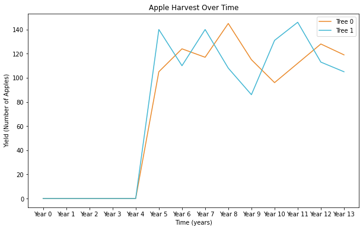

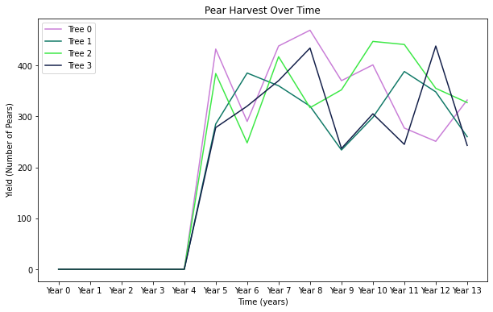

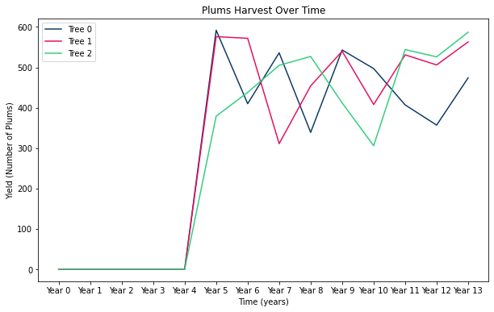

```python
# plot all apple trees produced in our orchard in one graph

# randomly create colors for all potential apple trees
color = ["#"+''.join([random.choice('0123456789ABCDEF') for j in range(6)])
             for i in range(len(apple_df.index))]

# set figure size
plt.figure(figsize=(10,6))

# for loop to iterate through dataframe
for i in range(len(apple_df.index)):
    x = apple_df.drop('Total', axis=1).columns[:-1].values
    y = apple_df.drop('Total', axis=1).iloc[i,:-1].values
    apples = plt.plot( x, y, color= color[i], linestyle='-', label='Tree {}'.format(i))

plt.xlabel('Time (years)')
plt.ylabel('Yield (Number of Apples)')
plt.title('Apple Harvest Over Time')
plt.legend()


# plot all pear trees produced in our orchard in one graph

# randomly create colors for all potential pear trees
color = ["#"+''.join([random.choice('0123456789ABCDEF') for j in range(6)])
             for i in range(len(pear_df.index))]

# set figure size
plt.figure(figsize=(10,6))

# for loop to iterate through dataframe
for i in range(len(pear_df.index)):
    x = pear_df.drop('Total', axis=1).columns[:-1].values
    y = pear_df.drop('Total', axis=1).iloc[i,:-1].values
    pears = plt.plot( x, y, color= color[i], linestyle='-', label='Tree {}'.format(i))

plt.xlabel('Time (years)')
plt.ylabel('Yield (Number of Pears)')
plt.title('Pear Harvest Over Time')
plt.legend()


# plot all plum trees produced in our orchard in one graph

# randomly create colors for all potential plum trees
color = ["#"+''.join([random.choice('0123456789ABCDEF') for j in range(6)])
             for i in range(len(plum_df.index))]

# set figure size
plt.figure(figsize=(10,6))

# for loop to iterate through dataframe
for i in range(len(plum_df.index)):
    x = plum_df.drop('Total', axis=1).columns[:-1].values
    y = plum_df.drop('Total', axis=1).iloc[i,:-1].values
    plt.plot( x, y, color= color[i], linestyle='-', label='Tree {}'.format(i))

plt.xlabel('Time (years)')
plt.ylabel('Yield (Number of Plums)')
plt.title('Plums Harvest Over Time')
plt.legend()
```

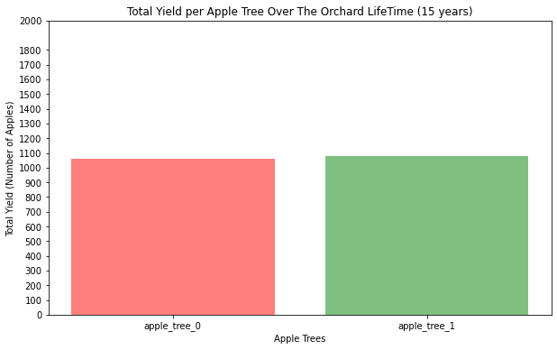

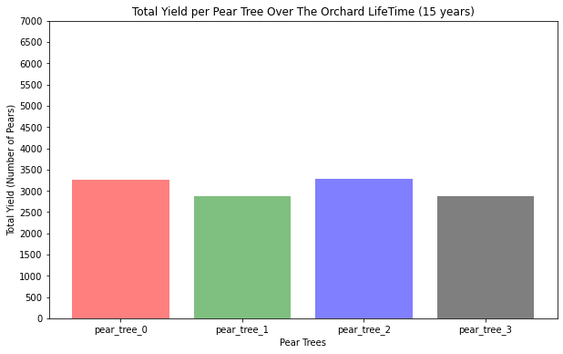

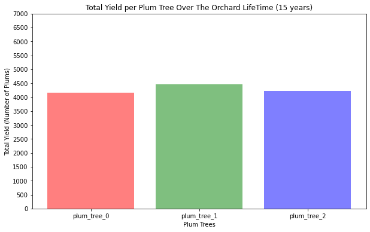

```python
# bar chart plots of the total fruit yielded per tree for each tree species (apple, pear, and plum)

# apple bar chart
plt.figure(figsize=(10,6))

plt.bar(apple_df['apple_tree'], apple_df['Total'], align='center', alpha=0.5, color = 'rgbkymc')

plt.xlabel("Apple Trees")
plt.ylabel("Total Yield (Number of Apples)")
plt.title('Total Yield per Apple Tree Over The Orchard LifeTime (15 years)')
plt.yticks([0,100,200,300,400,500,600,700,800,900,1000,1100,1200,1300,1400,1500,1600,1700,1800,2000])
plt.show()

# pear bar chart
plt.figure(figsize=(10,6))

plt.bar(pear_df['pear_tree'], pear_df['Total'], align='center', alpha=0.5, color = 'rgbkymc')

plt.xlabel("Pear Trees")
plt.ylabel("Total Yield (Number of Pears)")
plt.title('Total Yield per Pear Tree Over The Orchard LifeTime (15 years)')
plt.yticks([0,500,1000,1500,2000,2500,3000,3500,4000,4500,5000,5500,6000,6500,7000])
plt.show()

# plum bar chart
plt.figure(figsize=(10,6))

plt.bar(plum_df['plum_tree'], plum_df['Total'], align='center', alpha=0.5, color = 'rgbkymc')

plt.xlabel("Plum Trees")
plt.ylabel("Total Yield (Number of Plums)")
plt.title('Total Yield per Plum Tree Over The Orchard LifeTime (15 years)')
plt.yticks([0,500,1000,1500,2000,2500,3000,3500,4000,4500,5000,5500,6000,6500,7000])
plt.show()
```

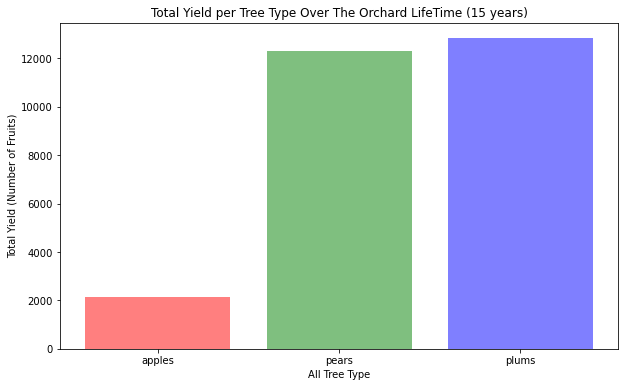

```python
# bar chart for fruit produced by each tree type
plt.figure(figsize=(10,6))

plt.bar(all_trees_df.index, all_trees_df['species_harvest'], align='center', alpha=0.5, color = 'rgbkymc')

plt.xlabel("All Tree Type")
plt.ylabel("Total Yield (Number of Fruits)")
plt.title('Total Yield per Tree Type Over The Orchard LifeTime (15 years)')
plt.show()
```

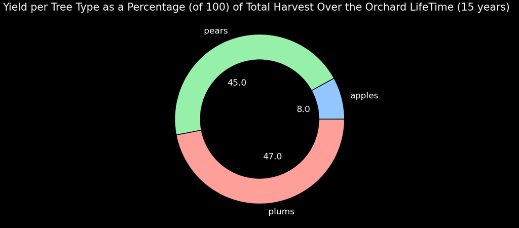

```python
# donut plot of each tree types harvest as a percentage of total fruit harvest over the entire lifetime of the Orchard (inspired by https://python-graph-gallery.com/donut-plot/)
#note: this cell must be run twice to make the text legible for some reason

# create data
trees = all_trees_df.index
size = round(all_trees_df['total_harvest_percentage'])
# trees ='apples', 'pears', 'plums'
# size = [19.114375, 45.271473, 35.614152]


# Create a circle for the center of the plot
my_circle=plt.Circle( (0,0), 0.7, color='black')


# give color names
plt.figure(figsize=(15,10), facecolor="k")
plt.pie(size, labels = trees, colors=['red','green', 'skyblue'])
p=plt.gcf()
p.gca().add_artist(my_circle)

# label color
plt.rcParams['text.color'] = 'white'
plt.title('Yield per Tree Type as a Percentage (of 100) of Total Harvest Over the Orchard LifeTime (15 years)  ')
plt.pie(size, labels=size, labeldistance=0.45, wedgeprops = { 'linewidth' : 2, 'edgecolor' : 'black' })
matplotlib.rcParams.update({'font.size': 22})
plt.show()
```

```python
# define X and Y for polynomial regression
X = apple_df_t['year'].astype('float').values
Y = apple_df_t['yearly_total'].astype('float').values
```

```python
k = 4
coef_np = np.polyfit(X, Y, deg=k) #basically numpy uses only this 1 line of code to perform the polynomial regression
coef = coef_np[::-1]
print_model(coef)
```

```
----------------------------------------------------------------------
        4         3        2
0.1728 x - 4.917 x + 42.4 x - 82.35 x + 14.17
----------------------------------------------------------------------
```

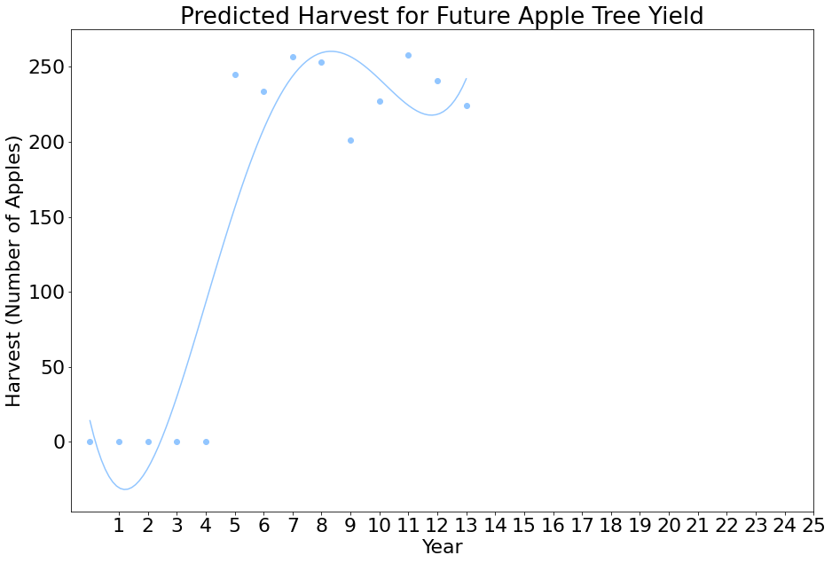

```python
# fit a line to the data pertaining to all apples produced over a 15 year orchard period in order to determine what future apple output could be
fig, ax = plt.subplots(figsize=(15,10))

plt.scatter(X, Y,  alpha=1)

plot_poly(ax, X, coef)

plt.xticks(np.arange(1,26, 1), ('1', '2', '3', '4', '5', '6', '7', '8', '9', '10', '11', '12', '13', '14', '15', '16',
                                '17', '18', '19', '20', '21', '22', '23', '24', '25'))
plt.xlabel("Year")
plt.ylabel("Harvest (Number of Apples)")
plt.title("Predicted Harvest for Future Apple Tree Yield", color = "k")
matplotlib.rcParams.update({'font.size': 10})

plt.show()
```

```python
# define X and Y for polynomial regression
X = pear_df_t['year'].astype('float').values
Y = pear_df_t['yearly_total'].astype('float').values
```

```python
k = 5
coef_np = np.polyfit(X, Y, deg=k) #basically numpy uses only this 1 line of code to perform the polynomial regression
coef = coef_np[::-1]
print_model(coef)
```

```
----------------------------------------------------------------------
          5         4         3         2
-0.02198 x + 1.661 x - 35.87 x + 283.2 x - 552.8 x + 106.3
----------------------------------------------------------------------
```

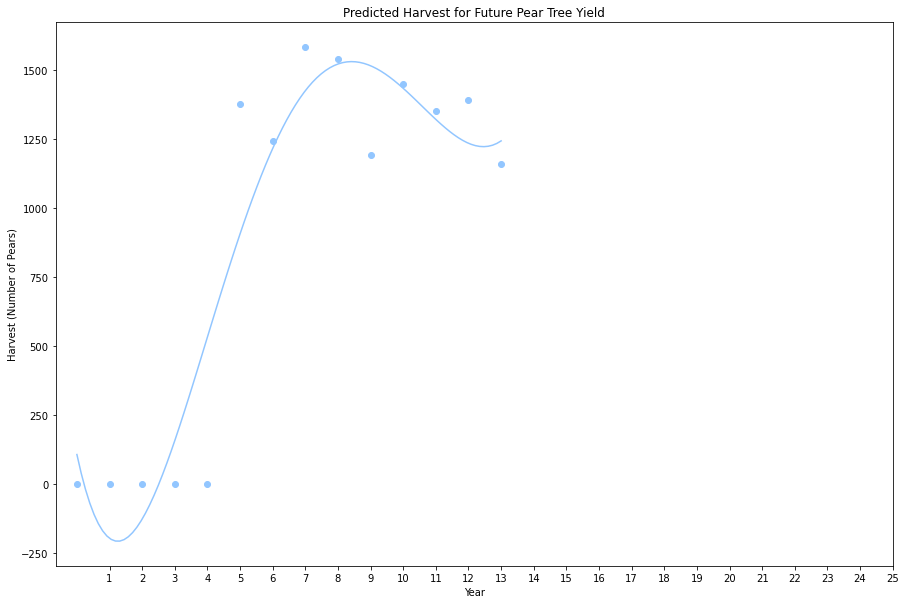

```python
# fit a line to the data pertaining to all pears produced over a 15 year orchard period in order to determine what future apple output could be
fig, ax = plt.subplots(figsize=(15,10))

plt.scatter(X, Y,  alpha=1)

plot_poly(ax, X, coef)

plt.xticks(np.arange(1,26, 1), ('1', '2', '3', '4', '5', '6', '7', '8', '9', '10', '11', '12', '13', '14', '15', '16',
                                '17', '18', '19', '20', '21', '22', '23', '24', '25'))
plt.xlabel("Year")
plt.ylabel("Harvest (Number of Pears)")
plt.title("Predicted Harvest for Future Pear Tree Yield", color = "k")
matplotlib.rcParams.update({'font.size': 10})

plt.show()
```

```python
# define X and Y for polynomial regression
X = plum_df_t['year'].astype('float').values
Y = plum_df_t['yearly_total'].astype('float').values
```

```python
k = 4
coef_np = np.polyfit(X, Y, deg=k) #basically numpy uses only this 1 line of code to perform the polynomial regression
coef = coef_np[::-1]
print_model(coef)
```

```
----------------------------------------------------------------------
       4         3         2
1.195 x - 32.68 x + 272.7 x - 525.7 x + 93.33
----------------------------------------------------------------------
```

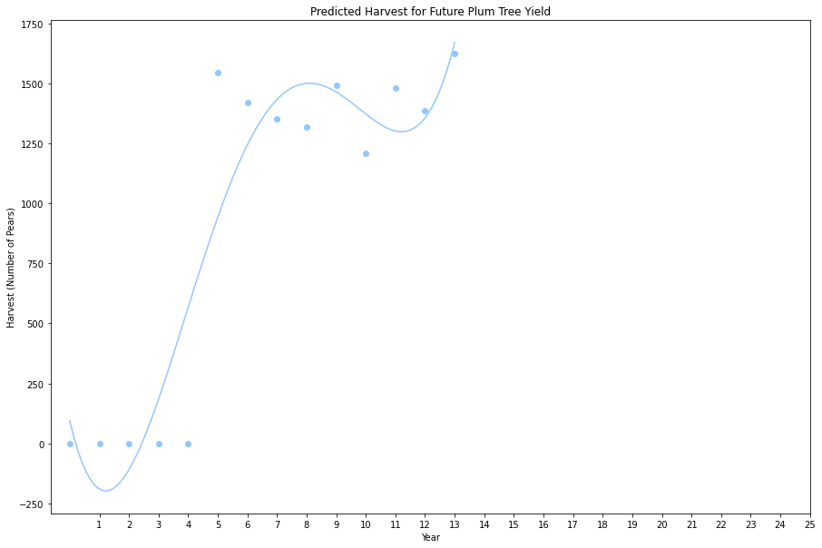

```python
# fit a line to the data pertaining to all pears produced over a 15 year orchard period in order to determine what future apple output could be
fig, ax = plt.subplots(figsize=(15,10))

plt.scatter(X, Y,  alpha=1)

plot_poly(ax, X, coef)

plt.xticks(np.arange(1,26, 1), ('1', '2', '3', '4', '5', '6', '7', '8', '9', '10', '11', '12', '13', '14', '15', '16',
                                '17', '18', '19', '20', '21', '22', '23', '24', '25'))
plt.xlabel("Year")
plt.ylabel("Harvest (Number of Pears)")
plt.title("Predicted Harvest for Future Plum Tree Yield", color = "k")
matplotlib.rcParams.update({'font.size': 10})

plt.show()
```

### **Line Graphs:**

The line graphs plotted above provide insight into the number of fruits harvested per each individual tree within a tree type over the lifetime (i.e. timeline) of the orchard. For all fruit types, it can be observed that all apple, pear, and plum trees provide a yearly yield of 0 fruits for the time before their literature associated maturation threshold. After maturing, all apple trees produce relatively similar yearly yields to one another over the lifetime (i.e. timeline) of the orchard. All pear trees also produce relatively similar yearly yields to one another, as does all plum trees.

### **Bar Charts:**

**Apples** The total yield of apples produced by each individual tree over the lifetime of the orchard has also been visualised with a bar chart. This visualisation indicates that all apple trees produce more or less the same total yield, of around 1000 apples.

**Pears** The total yield of pears produced by each individual tree over the lifetime of the orchard has also been visualised with a bar chart. This visualisation indicates that all pear trees produce more or less the same total yield, of around 3000 pears.

**Plums** The total yield of plums produced by each individual tree over the lifetime of the orchard has also been visualised with a bar chart. This visualisation indicates that all plum trees produce more or less the same total yield, of around 4000 plum.

### **Donut Chart:**

The donut chart above provides a visualisation method for observing each tree type harvest as a percentage of total fruit harvest over the entire lifetime of the orchard. As similarily observed in the all 'Total Yield per Tree Type Over The Orchard LifeTime (15 years)' bar chart, plums make up the largest proportion of total fruit yielded over the orchard's lifetime. Pears make up the second largest percentage of total fruit yielded over the orchard's lifetime, and apples make up the smallest percentage of total fruit yielded over the orchard's lifetime. For specific percentage allocations per tree type, please refer to the visualistion.

### **Polynomial Fitted Scatter Plots:**

**Apples** With data pertaining to total apple tree yield per year over the entire orchard timeline, a polynomial line has been fitted in order to help small-scale orchard farmers better determine future apple output for a timeline larger than of what we have considered. Results indicate that small-scale orchard farmers of this orchard should expect a total yearly harvest for future years to be somewhere between 200 and 250 apples per year.

**Pears** With data pertaining to total pear tree yield per year over the entire orchard timeline, a polynomial line has been fitted in order to help small-scale orchard farmers better determine future pear output for a timeline larger than of what we have considered. Results indicate that small-scale orchard farmers of this orchard should expect a total yearly harvest for future years to be somewhere between 1100 and 1500 pears per year.

**Plums** With data pertaining to total plum tree yield per year over the entire orchard timeline, a polynomial line has been fitted in order to help small-scale orchard farmers better determine future plum output for a timeline larger than of what we have considered. Results indicate that small-scale orchard farmers of this orchard should expect a total yearly harvest for future years to be somewhere between 1250 and 1600 plums per year.

# **5.0 Conclusion**

Our analysis indicates that all apple, pear, and plum trees are capable of producing a steady yield per year per tree. Plum trees, however, are capable of producing far more fruit per yield than both pear trees and apple trees. Apple trees produce the least fruit per yield of all tree types. When considering the overall harvest of the orchard for its entire timeline, plums also make up the greatest proportion of harvest fruit, followed by pear trees. Apples are the smallest proportion of total harvest fruit over the lifetime of the orchard. Results also indicate that for future yearly harvests, if small scale-orchard farmers of this orchard would like to continue farming after the indicated orchard timeline, farmers can expect future total yearly harvest of between 200-250 apples, 1100-1500 pears, and 1250-1600 plums.

Thus, in order to better combat food insecurity while mitigating against environmental damage from climate change, people looking to grow small-scale orchards should consider prioritising plum trees in their plantation over both pear and apple trees. Considering the FDA recommended 5-9 servings of fruits/vegetables per day, and assuming that one piece of fruit constitutes a single serving, planted plum trees are capable of providing significantly more nutrition to a farmer/community than pear and apple trees. In priotising plum trees over pear and apple trees in farming, a small-scale orchard may be more nutritionally viable.

# **6.0 Recommendations for Further Research**

In order to improve upon this current research, the following actions are recommended.

1. Further incorporate stochasticity, to better represent actual tree types, within the branch production. Such branch production and stochasticity could be better modelled after literature for each tree species’ branching.
2. Incorporate tree pruning at given time intervals. Model such pruning after real-life pruning practices, in order to better represent a real-life orchard. In doing so, more accurate fruit yields could be determined.
3. Optimise the location of tree planting based on tree canopy space in order to maximise land use while also preventing trees from growing into one another.
4. Incorporate additional data sources, pertinent to weather, in order to better represent the effects of climate on fruit production

With the above listed recommendations, this research could prove more reliable and insightful for small-scale orchard farmers in determining orchard viability and fruit production.

# **References**

Doherty, T. J., & Clayton, S. (2011). The psychological impacts of global climate change. *American Psychologist, 66*(4), 265. https://doi.org/10.1037/a0023141

Kumar, K., & Parikh, J. (2001). Socio-economic impacts of climate change on Indian agriculture. *International Review for Environmental Strategies, 2*(2). Retrieved from https://www.researchgate.net/publication/339295834_Socio-economic_Impacts_of_Climate_Change_on_Indian_Agriculture

Mijatović, D., Van Oudenhoven, F., Eyzaguirre, P., & Hodgkin, T. (2012). The role of agricultural biodiversity in strengthening resilience to climate change: towards an analytical framework. *International Journal of Agricultural Sustainability, 11*(2), 95-107. https://doi.org/10.1080/14735903.2012.691221

Ramanathan, V., & Feng, Y. (2009). Air pollution, greenhouse gases and climate change: GLobal and regional perspectives. **Atmospheric Environment**, 43, 37-50. doi:10.1016/j.atmosenv.2008.09.063

Rosa, E. A., Rudel, T. K., York, R., Jorgenson, A. K., & Dietz, T. THe Human (Anthropogenic) Driving Forces of Global Climate Change. In R. E. Dunlap & R. J. Brulle (Eds.), *Climate Change and Society: Sociological Perspectives* (p. 32-50). DOI: 10.1093/acprof:oso/9780199356102.001.0001